# ECON30024/ECON90024 - Assignment 1 - Q1 & Q2

### Q2b - (14 marks) For each price index, calculate the corresponding return series. Do this using the exact formula for calculating rates of return on a price index or use the log-difference approximation. Then use the Box-Ljung test (also called Ljung-Box test) to test the joint significance of the first 12 autocorrelations of each return series.

This is consistent with the weak form of the Efficient Market Hypothesis (EMH): the past prices (and therefore returns) are assumed to contain no useful information on future prices. If there was, there would be significant autocorrelation in this return series.

However, we need to consider these results in context of the joint hypothesis problem. Our failure to reject the null hypothesis, and therefore confirm the EMH, is actually conditional the assumption the data follows a random walk model. If our data does not follow a random walk (which we can’t confirm using this test), then our results are invalidated. However, conditional on the series being a random walk, we confirm the weak form of the EMH.

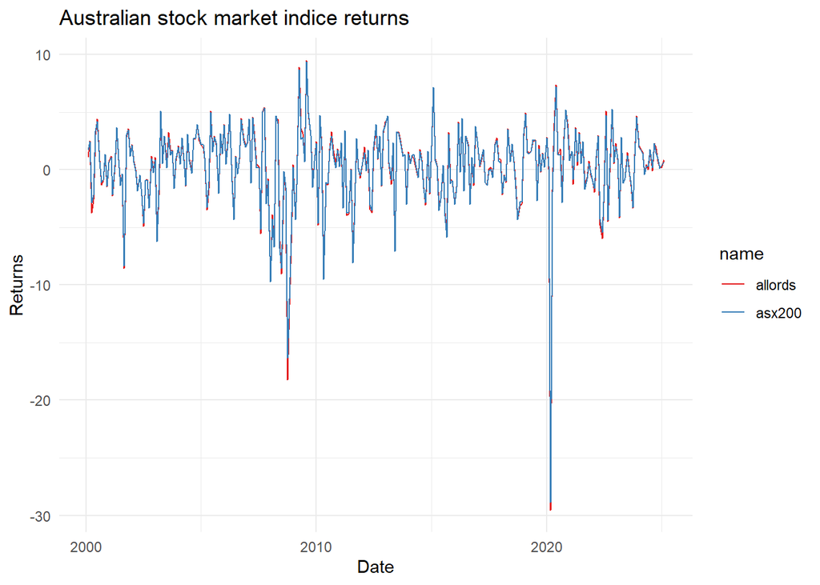

```r
# Calculating monthly returns

data <- data %>%
  group_by(name) %>%
  mutate(returns = ((value - lag(value)) / value) * 100) %>%
  na.omit()

ggplot(data, aes(date, returns, colour = name)) +
  geom_line() +
  labs(title = "Australian stock market indice returns",
       y = "Returns",
       x = "Date") +
  theme_minimal() +
  scale_color_brewer(palette = "Set1")
```

```r
# Conducting Box-Ljung test on allords

data %>%
  filter(name == "allords") %>%
  pull(returns) %>%
  Box.test(lag = 12, type = "Ljung-Box")
```

```
##
##  Box-Ljung test
##
## data:  .
## X-squared = 18.311, df = 12, p-value = 0.1066
```

```r
# Conducting Box-Ljung test on asx200

data %>%
  filter(name == "asx200") %>%
  pull(returns) %>%
  Box.test(lag = 12, type = "Ljung-Box")
```

```
##
##  Box-Ljung test
##
## data:  .
## X-squared = 16.063, df = 12, p-value = 0.1884
```

### Q2c - (14 marks) Use a unit root test or a regression to test whether the logarithm of each price index follows a random walk. For the regression analysis, you can estimate a simple regression as discussed on slide 11 of Topic 2 (if you don’t have much experience in Econometrics), or try to estimate the regression of Groenewold and Kang (1993) as given in Eq. (3) of the paper, or estimate an alternative regression that you think suitable.

In this test, as is the case of the Phillips-Perron (PP) test used by Groenewold and Kang (1993), the null hypothesis is the time series has a unit root - meaning it is non-stationary and therefore follows a random walk. The alternative hypothesis is the opposite: it does not have a unit root - meaning it is stationary and does not follow a random walk. This is a left-sided test, meaning we need the test statistics to be smaller than the relevant critical values to reject the null hypothesis at a given significance level.

When we test the allords index for the presence of a unit root we retrieve test statistics of -0.66 and -2.73 for the drift and drift and trend options. Neither of these test statistics are less than the 10 per cent critical value (-2.57 and -3.13 respectively), meaning we cannot reject the null hypothesis of allords following a random walk at any reasonable significance level.

We do the same for the ASX200 series, producing test statistics of -0.72 and -2.71 for the drift and drift and trend options. Again, neither of these are less than the 10 per cent critical value (-2.57 and -3.13 respectively), meaning we cannot reject the null hypothesis of asx200 following a random walk at any reasonable significance level.

These results support the weak form of the EMH, which says share prices reflect all past information, meaning future price movements are unpredictable base on past price data. Our failure to reject the null hypothesis of a random walk confirms this weak form of the EMH.

However, it’s important to be aware of the fact the testing EMH wit ha unit root test is not independent of the underlying model of asset prices. Failing to reject the null hypothesis doesn’t necessarily confirm EMH by itself as this test implicitly assumes it follows a random walk. If this is incorrect it could affect our conclusion. Therefore, our initial conclusion of confirming EMH is actually conditional on us assuming the data follows a random walk.

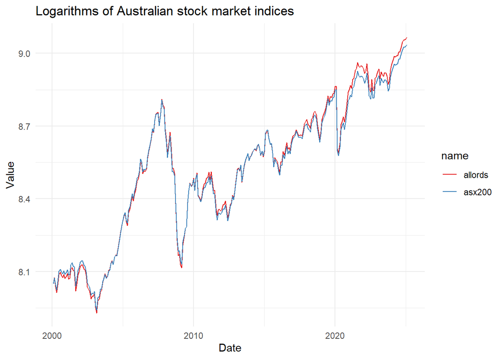

```r
# Turning price indexes into logarithms

data <- data %>%
  mutate(value_log = log(value))

ggplot(data, aes(date, value_log, colour = name)) +
  geom_line() +
  labs(title = "Logarithms of Australian stock market indices",
       y = "Value",
       x = "Date") +
  theme_minimal() +
  scale_color_brewer(palette = "Set1")
```

```r
# Producing ADF tests for the allords series

data %>%
  filter(name == "allords") %>%
  pull(value) %>%
  ur.df(type = "drift", selectlags = "AIC") %>%
  summary()
```

```
##
## ###############################################
## # Augmented Dickey-Fuller Test Unit Root Test #
## ###############################################
##
## Test regression drift
##
##
## Call:
## lm(formula = z.diff ~ z.lag.1 + 1 + z.diff.lag)
##
## Residuals:
##      Min       1Q   Median       3Q      Max
## -1620.67   -74.27    10.53    95.93   392.32
##
## Coefficients:
##              Estimate Std. Error t value Pr(>|t|)
## (Intercept) 40.515437  40.065912   1.011  0.31274
## z.lag.1     -0.004852   0.007358  -0.659  0.51019
## z.diff.lag   0.177054   0.057518   3.078  0.00228 **
## ---
## Signif. codes:  0 '***' 0.001 '**' 0.01 '*' 0.05 '.' 0.1 ' ' 1
##
## Residual standard error: 185.5 on 296 degrees of freedom
## Multiple R-squared:  0.03138,    Adjusted R-squared:  0.02484
## F-statistic: 4.795 on 2 and 296 DF,  p-value: 0.008922
##
##
## Value of test-statistic is: -0.6593 1.1948
##
## Critical values for test statistics:
##       1pct  5pct 10pct
## tau2 -3.44 -2.87 -2.57
## phi1  6.47  4.61  3.79
```

```r
data %>%
  filter(name == "allords") %>%
  pull(value) %>%
  ur.df(type = "trend", selectlags = "AIC") %>%
  summary()
```

```
##
## ###############################################
## # Augmented Dickey-Fuller Test Unit Root Test #
## ###############################################
##
## Test regression trend
##
##
## Call:
## lm(formula = z.diff ~ z.lag.1 + 1 + tt + z.diff.lag)
##
## Residuals:
##      Min       1Q   Median       3Q      Max
## -1615.74   -72.94    10.20    93.18   450.46
##
## Coefficients:
##              Estimate Std. Error t value Pr(>|t|)
## (Intercept) 135.71834   52.87111   2.567  0.01075 *
## z.lag.1      -0.04456    0.01631  -2.732  0.00667 **
## tt            0.75023    0.27571   2.721  0.00689 **
## z.diff.lag    0.19647    0.05735   3.426  0.00070 ***
## ---
## Signif. codes:  0 '***' 0.001 '**' 0.01 '*' 0.05 '.' 0.1 ' ' 1
##
## Residual standard error: 183.6 on 295 degrees of freedom
## Multiple R-squared:  0.0551, Adjusted R-squared:  0.04549
## F-statistic: 5.734 on 3 and 295 DF,  p-value: 0.0007964
##
##
## Value of test-statistic is: -2.7324 3.2819 3.9243
##
## Critical values for test statistics:
##       1pct  5pct 10pct
## tau3 -3.98 -3.42 -3.13
## phi2  6.15  4.71  4.05
## phi3  8.34  6.30  5.36
```

```r
# Producing ADF tests for the asx200 series

data %>%
  filter(name == "asx200") %>%
  pull(value) %>%
  ur.df(type = "drift", selectlags = "AIC") %>%
  summary()
```

```
##
## ###############################################
## # Augmented Dickey-Fuller Test Unit Root Test #
## ###############################################
##
## Test regression drift
##
##
## Call:
## lm(formula = z.diff ~ z.lag.1 + 1 + z.diff.lag)
##
## Residuals:
##      Min       1Q   Median       3Q      Max
## -1572.11   -73.16     9.70    94.20   386.04
##
## Coefficients:
##              Estimate Std. Error t value Pr(>|t|)
## (Intercept) 43.273008  40.745111   1.062  0.28908
## z.lag.1     -0.005537   0.007587  -0.730  0.46607
## z.diff.lag   0.166355   0.057607   2.888  0.00417 **
## ---
## Signif. codes:  0 '***' 0.001 '**' 0.01 '*' 0.05 '.' 0.1 ' ' 1
##
## Residual standard error: 180.7 on 296 degrees of freedom
## Multiple R-squared:  0.028,  Adjusted R-squared:  0.02143
## F-statistic: 4.263 on 2 and 296 DF,  p-value: 0.01495
##
##
## Value of test-statistic is: -0.7298 1.2259
##
## Critical values for test statistics:
##       1pct  5pct 10pct
## tau2 -3.44 -2.87 -2.57
## phi1  6.47  4.61  3.79
```

```r
data %>%
  filter(name == "asx200") %>%
  pull(value) %>%
  ur.df(type = "trend", selectlags = "AIC") %>%
  summary()
```

```
##
## ###############################################
## # Augmented Dickey-Fuller Test Unit Root Test #
## ###############################################
##
## Test regression trend
##
##
## Call:
## lm(formula = z.diff ~ z.lag.1 + 1 + tt + z.diff.lag)
##
## Residuals:
##      Min       1Q   Median       3Q      Max
## -1565.95   -73.79     8.72    92.51   441.68
##
## Coefficients:
##              Estimate Std. Error t value Pr(>|t|)
## (Intercept) 139.41009   54.09428   2.577  0.01045 *
## z.lag.1      -0.04429    0.01636  -2.708  0.00717 **
## tt            0.69630    0.26110   2.667  0.00808 **
## z.diff.lag    0.18539    0.05747   3.226  0.00140 **
## ---
## Signif. codes:  0 '***' 0.001 '**' 0.01 '*' 0.05 '.' 0.1 ' ' 1
##
## Residual standard error: 178.8 on 295 degrees of freedom
## Multiple R-squared:  0.05088,    Adjusted R-squared:  0.04123
## F-statistic: 5.272 on 3 and 295 DF,  p-value: 0.001483
##
##
## Value of test-statistic is: -2.7076 3.2047 3.8276
##
## Critical values for test statistics:
##       1pct  5pct 10pct
## tau3 -3.98 -3.42 -3.13
## phi2  6.15  4.71  4.05
## phi3  8.34  6.30  5.36
```